# Lesson15-GenomicDataIII

Anna Williford

### What you should know at the end of this lesson

```
#Skills
run BWA
understand alignment format (SAM format)
work with SAM/BAM files using samtools

#Terminology
alignment/mapping
SAM format
SAM flags
Cigar strings

#Commands
bwa commands
samtools commands
```

### Prep setup

```bash
#make MyWork_Lesson15 in CTools_Spring2017
mkdir MyWork_Lesson15

#connect to TACC, go to $WORK directory
ssh username@ls5.tacc.utexas.edu
cdw
#to avoid long download times, I have data for you in my $WORK directory
#copy BWA directory from my $WORK to your $WORK
cp -r /work/03444/awillifo/lonestar/BWA .


#open another terminal
#connect to TACC and start idev session (for working with samtools)
idev -m 80

#You now have 3 terminals open: one on local machine, 2 on TACC
```

### NGS data applications

Last time we talked about next-generation sequencing, the technology that generates millions of short sequences(reads). We mentioned that these reads can be assembled in longer stretches of DNA (contigs), and with some additional information, into chromosomes. That is, one application of NGS data is sequence assembly.

NGS data (short reads) can be used for other purposes. Can you think of some?

Here are some applications that use NGS data:  
-Studies of variation within species (between populations and between individuals):

- Single nucleotide polymorphism detection (SNP analysis)
- Copy number variation
- Structural variation (deletions, insertions, rearangements)

-Gene expresson analysis (using RNAseq data)  
-Genome annotation (using RNAseq data)  
-Metagenomics

The first 2 steps in nearly all applications that use NGS data (short reads in fastq files) are:

- Quality filtering (we did some of it in Lesson14)
- Read alignment (mapping) to reference sequence

#### Mapping reads to reference sequence

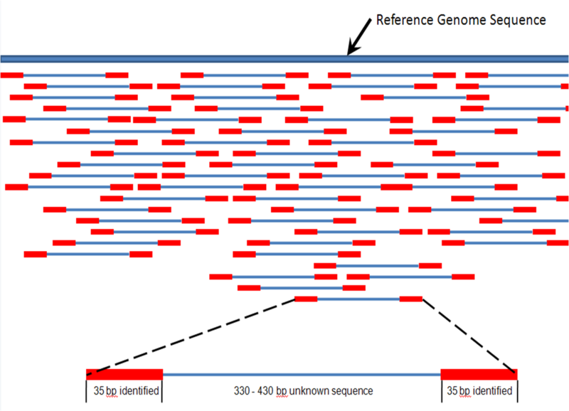

Image from: https://en.wikipedia.org/wiki/Genomics#/media/File:Mapping_Reads.png

There are many tools(programs) for mapping reads to reference sequence. You can read about diferent tools here: https://www.ecseq.com/support/ngs/what-is-the-best-ngs-alignment-software We will try out one of the aligning tools, BWA: http://bio-bwa.sourceforge.net/bwa.shtml

### BWA (Burrows-Wheeler Aligner)

BWA aligns short (low-divergent) reads to reference genome. The aligner has tons of options, we will use the defaults (but feel free to experiment). BWA takes short reads (in fastq format) and indexed genome as inputs and generates alignment output file in SAM format. Let’s try it out.

```bash
#From your login node:
#Go to BWA_run folder
cd $WORK/BWA/BWA_run

#The files you need to run BWA are here:
#read1.fastq and read2fastq contain subset of reads from SRR203502 https://www.ncbi.nlm.nih.gov/sra/?term=SRR203502 (from Lesson 14)
#These fastq files only contain reads that map to 3R chromosome and some reads that do not map to reference genome
#Drosophila melanogaster reference genome

#Open BWA_sbatch.sh with nano command-line editor
nano BWA_sbatch.sh
#Ctrl+X to exit nano

#if you modify this script, use `Ctrl+X` to save, then `y`, then `enter`
#does everything look good?
#submit your script (let's run it from current directory)
sbatch BWA_sbatch.sh
```

While your job is running, let’s see what output to expect

```bash
#Go to BWA/BWA_Anya
#see what is there
ls
#files with gz.* are files generated by `bwa index` command.
#BWA.o695566 #standard output and errors are redirected to this file
#ToDmelGenome.sam  #output of BWA in sam format

#View ToDmelGenome.sam
less ToDmelGenome.sam

#The file is large (~2.5 GB)
du -h ToDmelGenome.sam

#To undestand SAM format, let's take first 2000 lines
head -n 2000 ToDmelGenome.sam > ToDmelGenome_2000.sam

#no copy ToDmelGenome_2000.sam to your local machine, MyWork_Lesson15
#From your local MyWork_Lesson15: (copy from YOUR OWN directory)
$ scp awillifo@ls5.tacc.utexas.edu:/work/03444/awillifo/lonestar/BWA/BWA_Anya/ToDmelGenome_2000.sam .
```

### SAM format

SAM format is used to represent alignments of NGS reads

```bash
#open ToDmelGenome_2000.sam in your text editor
npp ToDmelGenome_2000.sam
```

SAM format:

```
#header
@SQ SN:XXXX LN:XXXX   #header lines indicating sequences present in genome fasta file and their lengths
@PG ID:XXX ... ...    #header line indicating program that generated sam file

#alignments
SRR203502.61    81  3R  7289113 60  146M    =   7289108 -151    CTC...  DEG...  NM:i:0  MD:Z:146    AS:i:146    XS:i:20
...
...
...
```

Go to this website to see what information is given in each field:  
http://www.htslib.org/doc/sam.html

Optional fields are set by alignment program, for BWA specifications, see:  
http://bio-bwa.sourceforge.net/bwa.shtml

#### Cigar strings

Cigar string lets you know how your read differs from the sequence you align your reads to.

```
Reference:        ACTTGGCTTA
ReadA(TTGGCT)       TTGGCT
Cigar String        6M          #M: matches/mismatches

Reference:        ACTTGGCTTA
ReadB(TTGGGT)       TTGGGT
Cigar String        6M          #M: matches/mismatches

Reference:        ACTTGGCTTA
ReadC(TTGGCTA)      TTGGC-TA
Cigar String        5M1D2M      #D: read contians 1 bp deletion relative to reference

Reference:        ACTT-GGCTTA
ReadD(TTAGGCTTA)    TTAGGCTTA
Cigar String        2M1I6M      #I: read contians 1 bp insertion relative to reference

Reference:        ACTTGGCTTA
ReadE(TTGGCCCG)     TTGGCccg    #S: read contians 3 analigned bases (S for soft-clipped)
Cigar String        5M3S        #S: ful read sequence will be present in SAM file

Reference:        ACTTGGCTTA
ReadF(TTGGCCCG)     TTGGCccg    #H: read contians 3 analigned bases (S for soft-clipped)
Cigar String        5M3H        #H: only matching sequence will be present in SAM file
```

Take a look at the cigar strings in `ToDmelGenome_2000.sam` (6th field). Hopefully they make more sense now.  
More on cigar strings:https://www.ncbi.nlm.nih.gov/pmc/articles/PMC2723002/

#### SAM flags

SAM flags provide additional information about read alignment.

Let’s work with the first 2 reads in `ToDmelGenome_2000.sam`. SAM flags are given in field 2: 81 and 161.  
Here is a nice tools that interpretes the meaning of these numbers for you.  
https://broadinstitute.github.io/picard/explain-flags.html

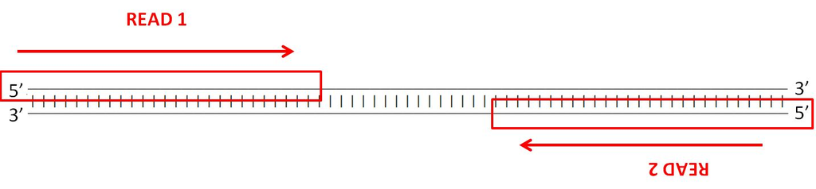

Could you make a diagram of alignment for these 2 reads? What is wrong here? Reads are overlapping, insert size is only 151 bp, but expected to be ~480bp. These two reads are not properly paired (wrong insert size)

#### Practice

```
Q1.Work with SRR203502.125 reads (reads 9 and 10 in ToDmelGenome_2000.sam). Understand what each field does, check flags and make a sketch of the alignment. What is different in this case?

Q2. Extract these reads from fastq files. Compare sequences in fastq and in SAM file. Do you get expected result? What is going on here?
grep -A3 'Regex'   #-A3 option allows to extract 3 lines that follow lines that match regex
```

#### Visualize alignments

We can visualize alignments with IGV software: http://software.broadinstitute.org/software/igv/ Download at home (it is available for all platforms) and play with it - this is extremely useful tool in genomics research.

Select the region (3R:16,739,900-16,740,500) that contains `SRR203502.125` reads. Find reads with information from SAM file. How do they differ from reference sequence? Do any of the changes look like true mutations? Or Sequencing errors?

### Samtools

Samtools is a command-line tool that includes many commands(functions) to manipulate SAM/BAM files. BAM file is a compressed version of SAM file, it is much smaller and faster to work with

```
#from compute node (idev session) window on lonestar
#load samtools module
load module samtools/1.3

####To see what commands are available, run `samtools` without arguments
samtools

####convert sam to bam with `samtools view` command
#see how to run `samtools view`
samtools view

#convert from sam to bam file
samtools view  -@48 -b ToDmelGenome.sam -o ToDmelGenome.bam

###sort bam file with `samtools sort` command (sorts by coordinates)
samtools sort -@48 ToDmelGenome.bam -o ToDmelGenome.sorted.bam

###index bam file with `samtools index` command
#(needed for IGV or extracting regions from the alignments )
samtools index ToDmelGenome.sorted.bam

###Count alignments (6832406)
samtools view -@48 -c ToDmelGenome.sorted.bam


###You can extract reads according to SAM flags
###Get mapped reads
-F option: do not include reads with flag 4 (flag 4 specifies unmapped reads)
samtools view -@48 -F4 -c ToDmelGenome.sorted.bam

#Get unmapped reads
-f option: include reads with flag 4
samtools view -@48 -f4 -c ToDmelGenome.sorted.bam
```

#### Practice

```
Q1. Count number of read in both fastq files. Compare this number to total alignments in sam/bam file. Can you figure out why these counts differ? Use ToDmelGenome.sam file, it is already sorted by read name

Q2. Are there any reads pairs such that one read maps to 3R and another to a different chromosome? Could you extract these reads to a new sam file?


Q3. This is best done at home, when you have IGV installed to visualize alignments.
Get alignment for region for 3R:25,832,000-25,843,000
`samtools view -Sh ToDmelGenome.sorted.bam 3R:25,832,000-25,843,000 > ToDmelGenome_3R_Region25.sam`
What is happening here? You might want to take a look at Drosophila GFF3 file.
```

### Resources

https://en.wikibooks.org/wiki/Next_Generation_Sequencing_(NGS)/Alignment  
https://www.ecseq.com/support/ngs/what-is-the-best-ngs-alignment-software http://www.cureffi.org/2012/12/19/forward-and-reverse-reads-in-paired-end-sequencing/

BWA documentation  
http://bio-bwa.sourceforge.net/bwa.shtml

SAM format  
http://www.htslib.org/doc/sam.html  
https://www.ncbi.nlm.nih.gov/pmc/articles/PMC2723002/

SAM flags  
https://broadinstitute.github.io/picard/explain-flags.html  
https://davetang.org/muse/2014/03/06/understanding-bam-flags/ https://ppotato.wordpress.com/2010/08/25/samtool-bitwise-flag-paired-reads/

IGV http://software.broadinstitute.org/software/igv/